# Working with pyspark

## Project description

You are an analyst for the Russian domestic airline F9. It is important to understand the preferences of users who buy tickets to different destinations.

You have to study the database and analyze the demand of passengers for flights to cities where the largest cultural festivals take place.

**query_1.csv** is the result of the first query. It contains the following information:

- *model* — **aircraft model;
- *flights_amount* — number of flights for each *model* aircraft model in September 2018.

**query_3.csv** is the result of the third query. It contains the following information:

- *city* — city;
- *average_flights* is the average number of flights arriving in a city (*city*) per day in September 2018.

# Analytics

```python
from pyspark import SparkContext
import numpy as np
import pandas as pd
from pyspark.sql import SparkSession
from pyspark.sql import HiveContext
import seaborn as sns
import matplotlib as plt
```

```python
APP_NAME = "DataFrames"
SPARK_URL = "local[*]"

spark = SparkSession.builder.appName(APP_NAME) \
        .config('spark.ui.showConsoleProgress', 'false') \
        .getOrCreate()#Create a SparkSession object

fly = spark.read.load('/datasets/query_1.csv',
                       format='csv', header='true', inferSchema='true')#Loading dataframe from csv file
```

```python
print(fly.describe().show())#I display the description of the data
```

```
+-------+-------------------+------------------+
|summary|              model|    flights_amount|
+-------+-------------------+------------------+
|  count|                  8|                 8|
|   mean|               null|          2035.625|
| stddev|               null|1965.2039470679445|
|    min|    Airbus A319-100|               300|
|    max|Sukhoi SuperJet-100|              4557|
+-------+-------------------+------------------+

None
```

```python
print(fly.show())#I output data
```

```
+-------------------+--------------+
|              model|flights_amount|
+-------------------+--------------+
|    Airbus A319-100|           607|
|    Airbus A321-200|           960|
|     Boeing 737-300|           630|
|     Boeing 767-300|           600|
|     Boeing 777-300|           300|
| Bombardier CRJ-200|          4446|
| Cessna 208 Caravan|          4557|
|Sukhoi SuperJet-100|          4185|
+-------------------+--------------+

None
```

```python
print(fly.printSchema())#I deduce the data type
```

```
root
 |-- model: string (nullable = true)
 |-- flights_amount: integer (nullable = true)

None
```

```python
fly.toPandas().info()#I deduce the data type
```

```
<class 'pandas.core.frame.DataFrame'>
RangeIndex: 8 entries, 0 to 7
Data columns (total 2 columns):
model             8 non-null object
flights_amount    8 non-null int32
dtypes: int32(1), object(1)
memory usage: 224.0+ bytes
```

Conclusion: The query_1.csv table was read normally, the data types correspond to reality. The table is small, consists of 8 rows.

```python
cityes = spark.read.load('/datasets/query_3.csv',
                       format='csv', header='true', inferSchema='true')
print(cityes.show())
```

```
+-------------+------------------+
|         city|   average_flights|
+-------------+------------------+
|       Абакан| 3.870967741935484|
|      Анадырь|               1.0|
|        Анапа| 2.161290322580645|
|  Архангельск| 5.354838709677419|
|    Астрахань|2.4516129032258065|
|      Барнаул|2.6129032258064515|
|     Белгород|               6.0|
|   Белоярский|               2.0|
| Благовещенск|               1.0|
|       Братск|               1.0|
|       Брянск|              10.0|
|     Бугульма|               3.0|
|  Владивосток|               3.0|
|  Владикавказ|               2.0|
|    Волгоград| 5.129032258064516|
|      Воркута| 4.580645161290323|
|      Воронеж|               2.0|
|    Геленджик| 2.590909090909091|
|Горно-Алтайск|1.3870967741935485|
|      Грозный| 1.129032258064516|
+-------------+------------------+
only showing top 20 rows

None
```

```python
print(cityes.describe().show())
```

```
+-------+---------+-----------------+
|summary|     city|  average_flights|
+-------+---------+-----------------+
|  count|      101|              101|
|   mean|     null|5.494189113891766|
| stddev|     null|13.11979040852178|
|    min|   Абакан|              1.0|
|    max|Ярославль|129.7741935483871|
+-------+---------+-----------------+

None
```

```python
print(cityes.printSchema())
```

```
root
 |-- city: string (nullable = true)
 |-- average_flights: double (nullable = true)

None
```

```python
cityes.toPandas().info()#I deduce the data type
```

```
<class 'pandas.core.frame.DataFrame'>
RangeIndex: 101 entries, 0 to 100
Data columns (total 2 columns):
city               101 non-null object
average_flights    101 non-null float64
dtypes: float64(1), object(1)
memory usage: 1.7+ KB
```

Conclusion: The query_3.csv table was read normally, the data types correspond to reality. The table consists of 101 lines.

```python
(cityes.toPandas()).sort_values('average_flights',ascending=False).head(10)# I display the top 10 cities by the number of flights
#print(spark.sql("SELECT city, average_flights FROM cityes GROUP BY city, average_flights ORDER BY average_flights DESC;").show(10))
```

|  | city | average_flights |
| --- | --- | --- |
| 43 | Москва | 129.774194 |
| 70 | Санкт-Петербург | 31.161290 |
| 54 | Новосибирск | 17.322581 |
| 33 | Красноярск | 11.580645 |
| 20 | Екатеринбург | 11.322581 |
| 67 | Ростов-на-Дону | 10.193548 |
| 63 | Пермь | 10.129032 |
| 10 | Брянск | 10.000000 |
| 74 | Сочи | 9.612903 |
| 84 | Ульяновск | 9.580645 |

I build a graph of the aircraft model and the number of flights.

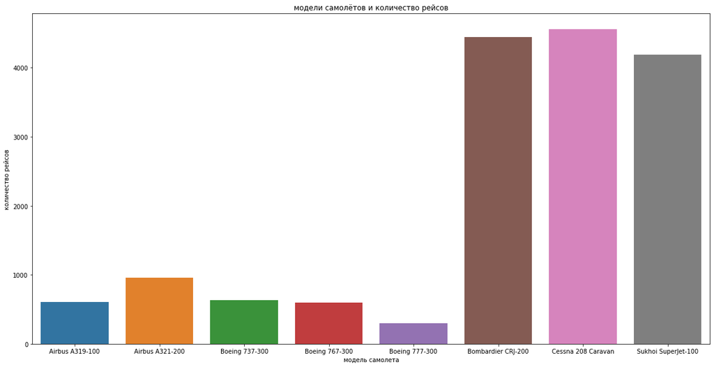

```python
plt.rcParams['figure.figsize']=(20,10)
ax = sns.barplot(x='model', y='flights_amount', data=fly.toPandas())
ax.set_title('aircraft models and number of flights')
ax.set_xlabel('airplane model')
ax.set_ylabel('number of flights')
```

As you can see, most of the flights are made by Cessna 208 Caravan, Bombardier CRJ-200, Sukhoi SuperJet-100.

I build a schedule of cities and the number of flights.

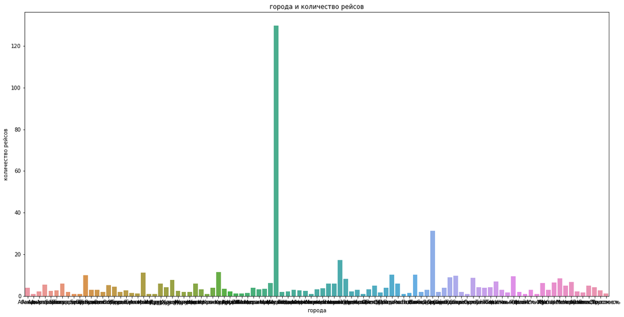

```python
plt.rcParams['figure.figsize']=(20,10)
ax = sns.barplot(x='city', y='average_flights', data=cityes.toPandas())
ax.set_title('cities and number of flights')
ax.set_xlabel('cities')
ax.set_ylabel('number of flights')
```

As you can see, two cities stand out the most, let's take a look at them.

```python
(cityes.toPandas()).loc[cityes.toPandas()['average_flights'] > 20]
```

|  | city | average_flights |
| --- | --- | --- |
| 43 | Москва | 129.774194 |
| 70 | Санкт-Петербург | 31.161290 |

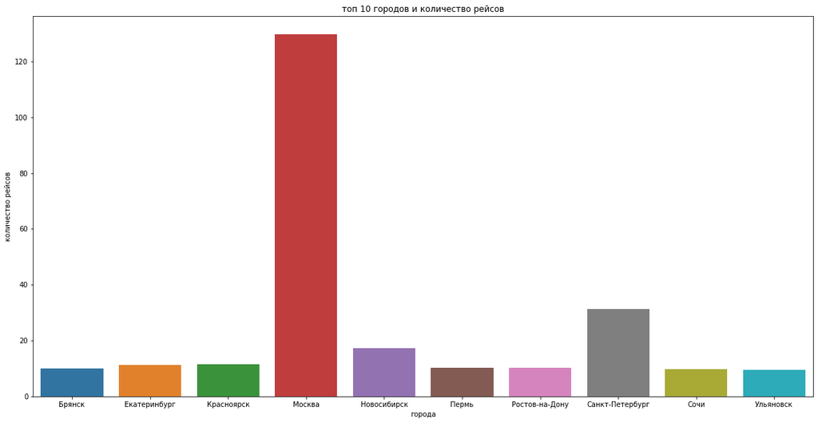

```python
plt.rcParams['figure.figsize']=(20,10)
ax = sns.barplot(x='city', y='average_flights', data=(cityes.toPandas()).loc[cityes.toPandas()['average_flights'] > 9.58])
ax.set_title('top 10 cities and number of flights')
ax.set_xlabel('cities')
ax.set_ylabel('number of flights')
```

Again, two cities stand out: Moscow and St. Petersburg.